# HW1_TS

Shan TANG STUDETID:20657299

## Problem 1: Semideﬁnite program

Code and result are as follows:

```r
library(CVXR)
w=c(0.1,0.2)
Sigma <- Variable(2,2,PSD=TRUE)
obj <- quad_form(w, Sigma)
constr1 <- list(Sigma[1,1] == 0.2, Sigma[1,2] >= 0.1,Sigma[1,2] <=0.7,
               Sigma[2,2] == 0.1, Sigma[2,1] >= -0.5,Sigma[2,1] <=0.4)

prob <- Problem(Maximize(obj), constr1)
result <- solve(prob)
result
```

[output not shown]

[output cut: 29 more lines]

[output not shown]

## Problem 2: Entropy maximization

**a**  
As negative entropy f(x)=xlogx is strictly convex on domains, and f is concave if -f in convex, f(x)=-xlog(x) is convave. Therefore, $_{i=1}^{n} $ wilog(wi) is concave.

**b**  
Code for Prob2 is as follows.

```r
m<-500
n<-100
set.seed(22)
X<-matrix(rnorm(m*n),m,n)
b<-t(X)%*% as.vector(rep(1/m,m))+rnorm(n,0,0.005)
w<-Variable(m)
obj <- sum(entr(w))
constr<-list(w>=0,sum(w)==1,t(X)%*%w==b)
prob <- Problem(Maximize(obj),constr)
result <- solve(prob)
```

Here is the error plot:

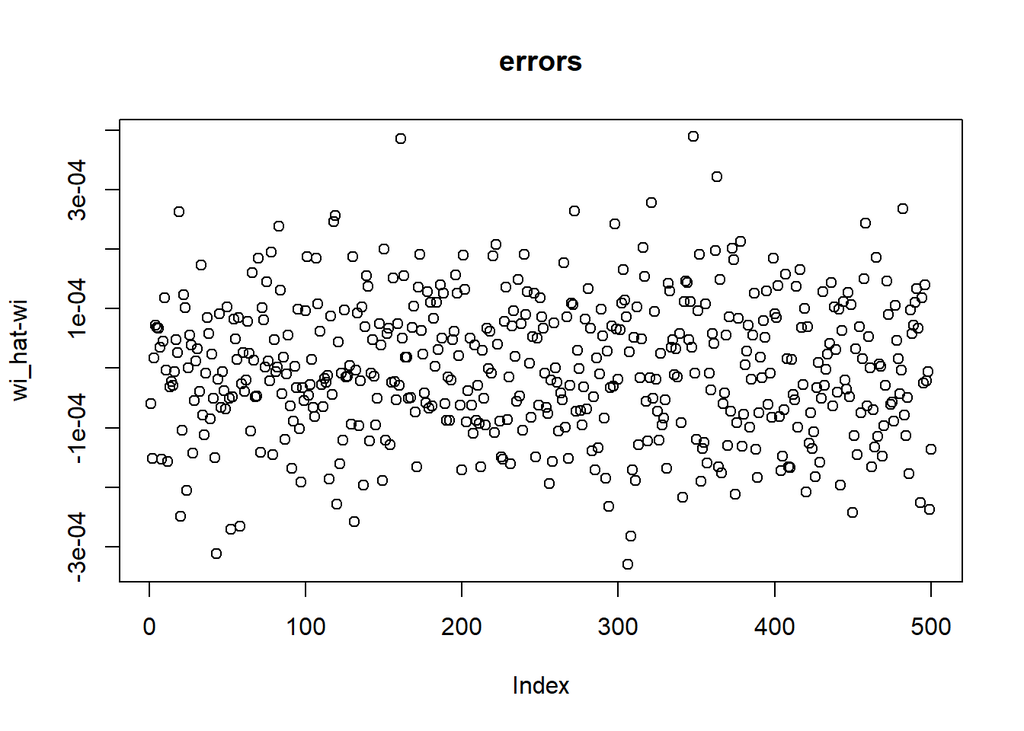

```r
er=result$getValue(w)-rep(1/m,m)
plot(er,main="errors",ylab="wi_hat-wi")
```

## Problem 3: Least Squares

**a**  
We can use the R base linear model fitting function lm() to solve least squere problem:

```r
m<-200
n<-20
beta_true<-c(-(n/2-1):(n/2))
set.seed(22)
X<-matrix(rnorm(m*n),m,n)
y<-X%*% as.vector(beta_true)+rnorm(m,0,10)*c(rep(0,m/2),rep(1,m/2))+rnorm(m,0,5)
res<-lm(y~0+X)
res
```

```
##
## Call:
## lm(formula = y ~ 0 + X)
##
## Coefficients:
##      X1       X2       X3       X4       X5       X6       X7       X8
## -9.9401  -8.0551  -6.8674  -5.9317  -4.3462  -3.9212  -2.6745  -1.3130
##      X9      X10      X11      X12      X13      X14      X15      X16
## -1.1333   0.1665   0.9603   1.2124   3.6084   3.2881   5.4943   5.5954
##     X17      X18      X19      X20
##  6.9270   9.3779   8.5776  10.4216
```

we can also cope it with CVXR:

```r
beta <- Variable(n)
obj <- sum((y - X %*% beta)^2)
prob <- Problem(Minimize(obj))
result <- solve(prob)
str(result)
```

```
## List of 9
##  $ 319         : num [1:20, 1] -9.94 -8.06 -6.87 -5.93 -4.35 ...
##  $ value       : num 13970
##  $ status      : chr "optimal"
##  $ getValue    :function (objet)
##  $ getDualValue:function (objet)
##  $ solver      : chr "OSQP"
##  $ solve_time  : num 0.00247
##  $ setup_time  : num NA
##  $ num_iters   : num 50
```

Output are of course the same with different tools.

**b**

```r
error<-rep(2.4,20)
for (i in 1:20){
    w<-c(rep(i,times=m/2),rep(1,times=m/2))
    beta <- Variable(n)
    obj <- sum(w*(y - X %*% beta)^2)
    prob <- Problem(Minimize(obj))
    result <- solve(prob)
    beta_hat=result$getValue(beta)
    error[i]<-sum((beta_true-beta_hat)^2)}
error
```

```
##  [1] 6.133149 4.030279 3.517334 3.364643 3.328528 3.336318 3.361404 3.392826
##  [9] 3.425767 3.458057 3.488750 3.517480 3.544168 3.568870 3.591705 3.612815
## [17] 3.632349 3.650449 3.667247 3.682866
```

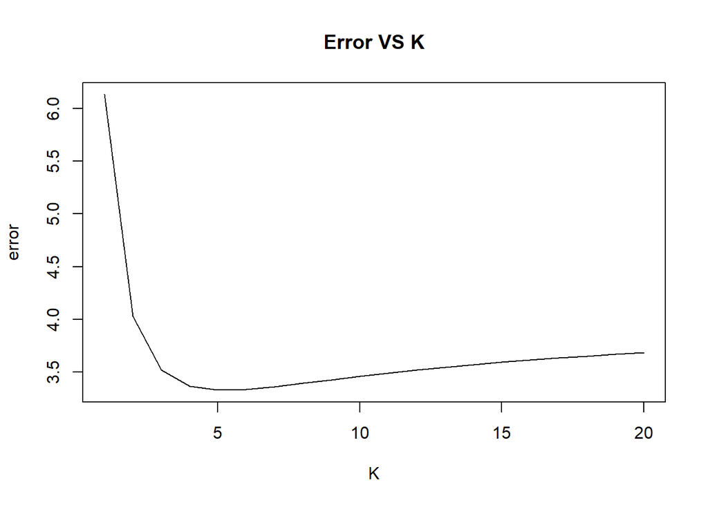

```r
plot(error,type="l",main="Error VS K",xlab="K")
```

**c**  
It is easily observed that as K grows, total error shrinks instantly and then goes up gradually. At K is close to 5, error is lowest.

Assume output is: $\hat{y}$=$X^{T}$$\beta$+$\varepsilon$,where$\varepsilon$is normally distributed.

Minimized objective can be achived by least negative loglikehood of output if we set $\sigma^{2}$=1/w. If we add replicated data points, Which is equalent to lager K, wi would be smaller, which contributes to lower error. However, on the contrary, as K grows larger, data are copied, data dependent variance goes up, which results in worse accuracy. with these two influence of bigger K, error would be lowest when we find a banlance point between low data dependent variance and good $\sigma^{2}$i.

## Problem 4: Convexity

**a** f(x) is defined on $R^{n}$->R, g(t)is defined at R->R.  
g(t)=f(Z+tV)  
dom g={t|x+tV}

**b**

```r
n = 4
set.seed (22)
a0 <- matrix (rnorm(n*n) , n)
A0 <- (a0 + t (a0) )/2 + 6 * diag ( rep (1 ,n) )
a1 <- matrix (rnorm(n*n) , n)
A1 <- (a0 + t (a0) )/2 + 1 * diag ( rep (1 ,n) )
a2 <- matrix (rnorm(n*n) , n)
A2 <- (a0 + t (a0) )/2
a3 <- matrix (rnorm(n*n) , n)
A3 <- (a0 + t (a0) )/2 + 2 * diag ( rep (1 ,n) )
a4 <- matrix (rnorm(n*n) , n)
A4 <- (a0 + t (a0) )/2
X <- matrix (rnorm(n*n) ,n ,n)
Z <- matrix (rnorm(n*n) ,n ,n)
```

```r
t<-c()
gt<-c()#define t and gt
interval<-seq(-50,50,0.1)
length(interval)#assume a rough range of t
```

```
## [1] 1001
```

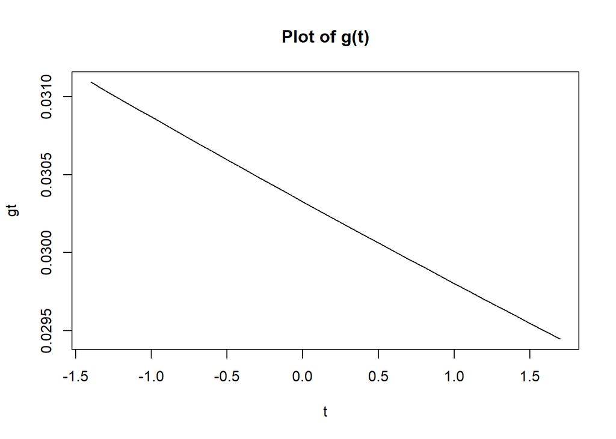

```r
for(i in 1:length(interval)){
    Xtemp<-X+interval[i]*Z
    d<-diag(Xtemp)      #diaognal elements of X
    f1<-A0+d[1]*A1+d[2]*A2+d[3]*A3+d[4]*A4
    if( (eigen(f1)$values[1]>0)&&(eigen(f1)$values[2] > 0)&&(eigen(f1)$values[3] > 0)&&(eigen(f1)$values[4] > 0)){
    #this is to check whether t_rough belongs to domains of g(t)
        t[i]<-interval[i]
        gt[i]<-1/sum(diag(f1))
    }
}
plot(t,gt,type="l",main="Plot of g(t)")
```

**c** f(x) is convex and reasons are demonstrated:

Define g(t)=f(Z+tV),where Z>0 and V $S^{n}$.

g(t)=$tr(Z+tV)^{-1}$  
=$tr((Z+tV)^{-1})$  
=tr( $Z^{-1}$ (I+t $Z^{-1/2}$ V $Z^{-1/2}$ $)^{-1}$ )

We use the eigenvalue decomposition $Z^{-1/2}$ V $Z^{-1/2}$ = Q $\Lambda$ $Q^{T}$

=tr($Z^{-1}$Q (I+T $\Lambda$ $)^{-1}$ $Q^{T}$)  
=tr($Q^{T}$ $Z^{-1}$ Q $(I+T \Lambda)^{-1}$)  
=$\sum_{i=1}^{n}$ ($Q^{T}$ $Z^{-1}$ Q $)_{ii}$ $(1+t \lambda )^{-1}$

g(t) is expressed as a possitive weighted sum of convex functions. Therefore, $tr(X)^{-1}$ is concave, besides,A0 + x1A1 +···+ xnAn is affine, the whole f(x) is convex.